# Instagram Usage & Lifestyle: How Social Media Affects Student Well-Being

Eldar Aliev & Chris Chew

2026-02-27

# Introduction

## Dataset

The dataset used in this project is the [Instagram Users & Lifestyle Dataset](https://www.kaggle.com/datasets/) from Kaggle. It contains **1,547,896 observations** across **58 variables**, covering a wide range of data about Instagram users including demographics (age, gender, country, income level), Instagram usage patterns (daily active minutes, sessions per day, reels watched, likes given), as well as lifestyle and health information (perceived stress, sleep hours, exercise, BMI, happiness).

Each row represents a single Instagram user, and the variables capture both how they use the platform and how they live their day-to-day lives.

## Motivation

Social media, especially Instagram — plays a massive role in the lives of young people today. As students, we are curious to find out how time spent on Instagram relates to well-being outcomes like stress. This dataset gives us the chance to explore whether heavier Instagram usage is associated with higher stress levels, and whether factors like sleep, income, or education influence that relationship. Understanding these patterns can help students make more informed choices about their screen time habits.

## Loading the Data

```r
df_raw <- readr::read_csv("instagram_users_lifestyle.csv", show_col_types = FALSE)
glimpse(df_raw)
```

```
## Rows: 1,547,896
## Columns: 58
## $ user_id                        <dbl> 1, 2, 3, 4, 5, 6, 7, 8, 9, 10, 11, 12, …
## $ app_name                       <chr> "Instagram", "Instagram", "Instagram", …
## $ age                            <dbl> 51, 64, 41, 27, 55, 20, 33, 51, 31, 35,…
## $ gender                         <chr> "Female", "Female", "Female", "Non-bina…
## $ country                        <chr> "India", "United Kingdom", "Canada", "S…
## $ urban_rural                    <chr> "Rural", "Urban", "Urban", "Urban", "Ur…
## $ income_level                   <chr> "High", "Middle", "Middle", "Middle", "…
## $ employment_status              <chr> "Retired", "Full-time employed", "Stude…
## $ education_level                <chr> "Bachelor’s", "Other", "Bachelor’s", "M…
## $ relationship_status            <chr> "Single", "Divorced", "In a relationshi…
## $ has_children                   <chr> "No", "No", "No", "No", "No", "Yes", "N…
## $ exercise_hours_per_week        <dbl> 7.2, 10.9, 5.0, 10.6, 7.7, 5.2, 6.5, 10…
## $ sleep_hours_per_night          <dbl> 7.7, 8.6, 6.7, 6.5, 6.8, 5.8, 7.7, 7.7,…
```

[output cut: 45 more lines]

## Summary Statistics

Below are summary statistics for two key variables in the full dataset: daily active minutes on Instagram and perceived stress score.

```r
summary_tbl <- df_raw %>%
  summarize(
    n                = n(),
    minutes_mean     = mean(daily_active_minutes_instagram, na.rm = TRUE),
    minutes_sd       = sd(daily_active_minutes_instagram, na.rm = TRUE),
    minutes_median   = median(daily_active_minutes_instagram, na.rm = TRUE),
    minutes_iqr      = IQR(daily_active_minutes_instagram, na.rm = TRUE),
    minutes_min      = min(daily_active_minutes_instagram, na.rm = TRUE),
    minutes_max      = max(daily_active_minutes_instagram, na.rm = TRUE),
    stress_mean      = mean(perceived_stress_score, na.rm = TRUE),
    stress_sd        = sd(perceived_stress_score, na.rm = TRUE),
    stress_median    = median(perceived_stress_score, na.rm = TRUE),
    stress_iqr       = IQR(perceived_stress_score, na.rm = TRUE),
    stress_min       = min(perceived_stress_score, na.rm = TRUE),
    stress_max       = max(perceived_stress_score, na.rm = TRUE)
  ) %>%
  pivot_longer(everything(), names_to = "metric", values_to = "value")

summary_tbl
```

```
## # A tibble: 13 × 2
##    metric             value
##    <chr>              <dbl>
##  1 n              1547896
##  2 minutes_mean       188.
##  3 minutes_sd         110.
##  4 minutes_median     186
##  5 minutes_iqr        170
##  6 minutes_min          5
##  7 minutes_max        580
##  8 stress_mean         20.0
##  9 stress_sd           11.8
## 10 stress_median       20
## 11 stress_iqr          20
## 12 stress_min           0
## 13 stress_max          40
```

The average Instagram user in the dataset spends about 188 minutes per day on the app (just over 3 hours), with a wide range from 5 to 580 minutes. The average perceived stress score is around 20 out of 40, this suggests moderate stress levels overall. Both variables show substantial variation, which makes them a greate option for further analysis.

## Filtering to Our Target Population

For the rest of this analysis, we focus on **U.S. students under 25** — a population that is both relevant to our research question and personally relatable.

```r
df_b <- df_raw %>%
  filter(app_name == "Instagram") %>%
  filter(country == "United States",
         age < 25,
         employment_status == "Student") %>%
  drop_na(daily_active_minutes_instagram,
          sessions_per_day,
          perceived_stress_score,
          income_level,
          education_level)

nrow(df_b)
```

```
## [1] 11335
```

After filtering, we have **11,335 observations** to work with — a strong sample size for our analyses.

# Visualizations

## Plot 1: Daily Instagram Minutes vs. Perceived Stress (Quantitative–Quantitative)

[figure not shown]

```r
ggplot(data = df_b, aes(x = daily_active_minutes_instagram,
                        y = perceived_stress_score)) +
  geom_point(alpha = 0.09, color = "steelblue") +
  geom_smooth(method = "lm", se = TRUE, color = "green") +
  labs(
    title = "Daily Instagram Minutes vs. Perceived Stress (US Students Under 25)",
    x     = "Daily Active Minutes on Instagram",
    y     = "Perceived Stress Score"
  ) +
  theme_minimal()
```

**Interpretation:** The scatterplot shows a positive association between daily Instagram minutes and perceived stress for U.S. students under 25. As daily minutes increase, stress scores tend to rise as well, and the regression line reflects this upward trend. However, there is still substantial spread at most usage levels, which tells us that Instagram time alone does not fully explain differences in stress.

## Plot 2: Perceived Stress by Income Level (Categorical–Quantitative)

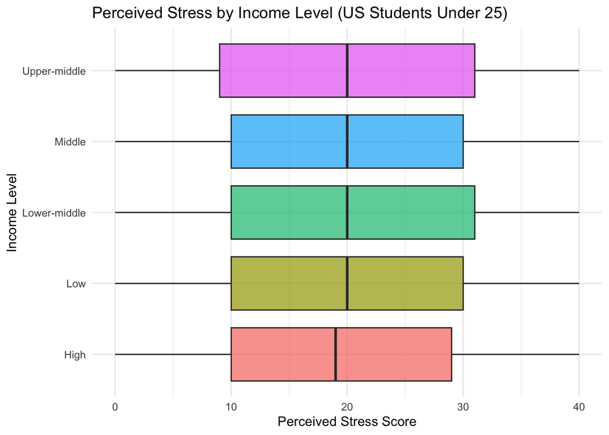

```r
ggplot(data = df_b,
       aes(x = fct_reorder(income_level, perceived_stress_score, .fun = median),
           y = perceived_stress_score,
           fill = income_level)) +
  geom_boxplot(alpha = 0.7) +
  coord_flip() +
  labs(
    title = "Perceived Stress by Income Level (US Students Under 25)",
    x     = "Income Level",
    y     = "Perceived Stress Score"
  ) +
  theme_minimal() +
  theme(legend.position = "none")
```

**Interpretation:** Stress levels look relatively similar across income groups for U.S. students under 25, with medians clustering in the low 20s. The high-income group has a slightly lower median stress compared to the other categories, but that difference is mildly noticeable. Overall, income level does not appear to create large differences in perceived stress in this filtered sample, although there is substantial variation within every group.

# Dataset Manipulations

## Stress by Instagram Usage Quartile

This dplyr manipulation divides students into four equal-sized groups based on their daily Instagram minutes, then calculates the mean stress and standard error for each quartile. This method allows us to see a more distinguished pattern.

```r
df_quart <- df_b %>%
  mutate(usage_quartile = ntile(daily_active_minutes_instagram, 4)) %>%
  group_by(usage_quartile) %>%
  summarize(
    mean_stress = mean(perceived_stress_score),
    se_stress   = sd(perceived_stress_score) / sqrt(n()),
    n           = n(),
    .groups     = "drop"
  )

df_quart
```

```
## # A tibble: 4 × 4
##   usage_quartile mean_stress se_stress     n
##            <int>       <dbl>     <dbl> <int>
## 1              1        7.05     0.104  2834
## 2              2       15.3      0.140  2834
## 3              3       24.7      0.141  2834
## 4              4       33.0      0.103  2833
```

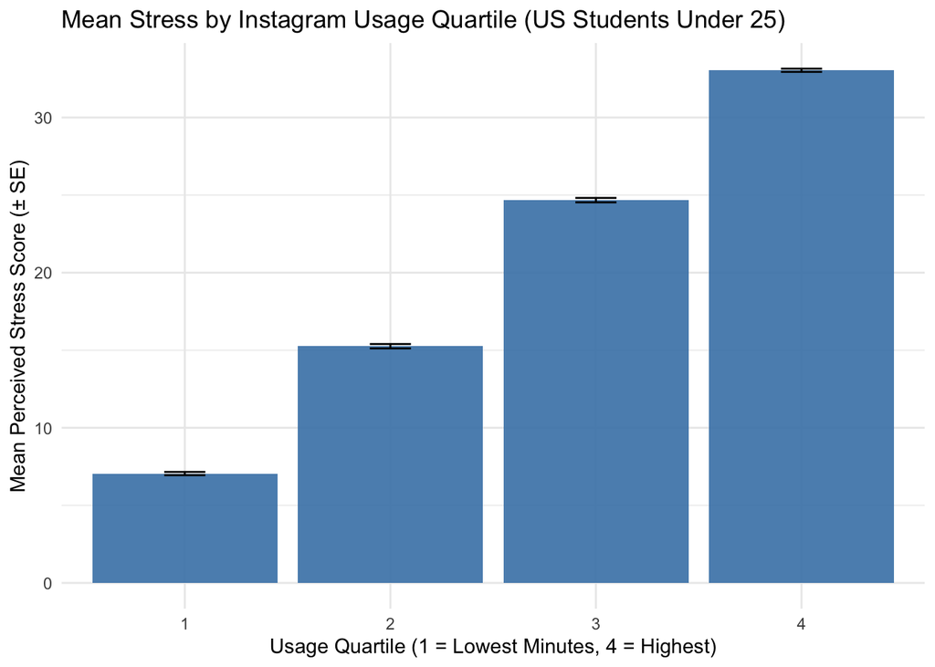

```r
ggplot(data = df_quart, aes(x = factor(usage_quartile), y = mean_stress)) +
  geom_col(fill = "steelblue", alpha = 0.9) +
  geom_errorbar(aes(ymin = mean_stress - se_stress,
                     ymax = mean_stress + se_stress),
                width = 0.2) +
  labs(
    title = "Mean Stress by Instagram Usage Quartile (US Students Under 25)",
    x     = "Usage Quartile (1 = Lowest Minutes, 4 = Highest)",
    y     = "Mean Perceived Stress Score (± SE)"
  ) +
  theme_minimal()
```

**Interpretation:** Mean stress increases steadily from quartile 1 (7.05) to quartile 4 (33.0), with minimal overlap in the standard error bars. This confirms that students who spend more time on Instagram report substantially higher perceived stress. Grouping by quartile makes this stepped pattern easy to see and highlights the large gap between low-use and high-use groups.

## Heatmap: Stress by Usage Quartile × Sleep Group

This manipulation combines two dplyr operations: 1. creating usage quartiles and categorizing sleep hours — to explore whether sleep moderates the usage–stress relationship.

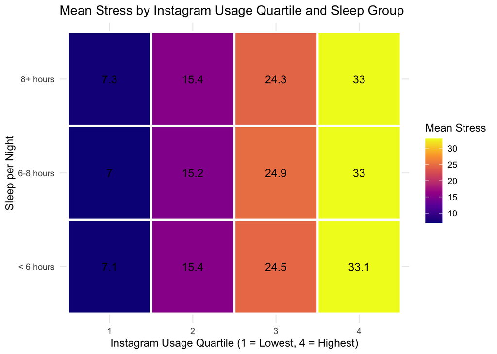

```r
df_heat <- df_b %>%
  mutate(
    usage_quartile = ntile(daily_active_minutes_instagram, 4),
    sleep_group = case_when(
      sleep_hours_per_night < 6 ~ "< 6 hours",
      sleep_hours_per_night < 8 ~ "6-8 hours",
      TRUE                      ~ "8+ hours"
    )
  ) %>%
  group_by(usage_quartile, sleep_group) %>%
  summarize(
    mean_stress = mean(perceived_stress_score),
    n           = n(),
    .groups     = "drop"
  )

ggplot(df_heat, aes(x = factor(usage_quartile), y = sleep_group, fill = mean_stress)) +
  geom_tile(color = "white", linewidth = 1) +
  geom_text(aes(label = round(mean_stress, 1)), size = 4) +
  scale_fill_viridis_c(option = "C") +
  labs(
    title = "Mean Stress by Instagram Usage Quartile and Sleep Group",
    x     = "Instagram Usage Quartile (1 = Lowest, 4 = Highest)",
    y     = "Sleep per Night",
    fill  = "Mean Stress"
  ) +
  theme_minimal()
```

**Interpretation:** Stress rises sharply from usage quartile 1 to 4 in every sleep group, and the values are nearly identical across sleep categories within each quartile. This tells us that Instagram usage is the dominant factor here — sleep group does not meaningfully change the usage–stress relationship in this sample.

## Faceted Scatter: Sessions per Day vs. Stress by Education Level

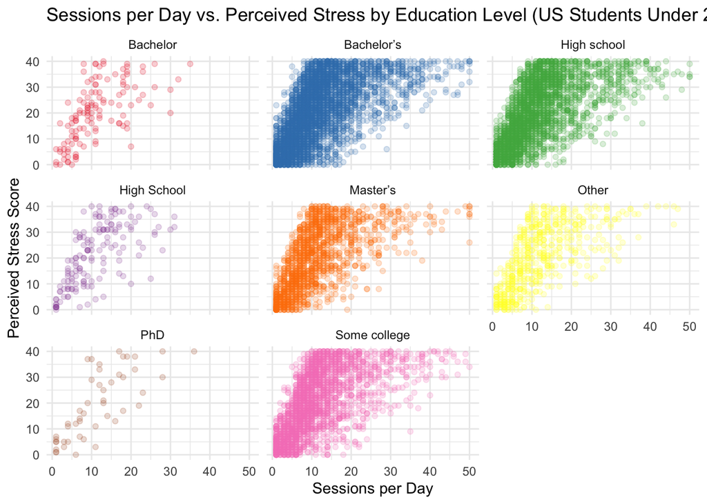

```r
ggplot(df_b, aes(x = sessions_per_day,
                 y = perceived_stress_score,
                 color = education_level)) +
  geom_point(alpha = 0.20) +
  facet_wrap(~ education_level) +
  labs(
    title = "Sessions per Day vs. Perceived Stress by Education Level (US Students Under 25)",
    x     = "Sessions per Day",
    y     = "Perceived Stress Score",
    color = "Education Level"
  ) +
  scale_color_brewer(palette = "Set1") +
  theme_minimal() +
  theme(legend.position = "none")
```

**Interpretation:** Every education graph shows a clear upward trend, meaning more sessions per day corresponds to higher stress — with a similar shape across all groups. This suggests that the sessions to stress relationship holds regardless of education level.

## 2D Histogram: Exercise Hours vs. Daily Instagram Minutes

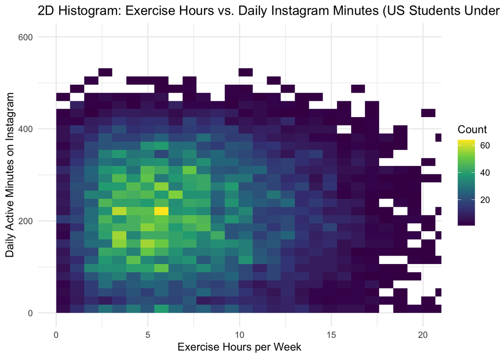

```r
df_2d <- df_b %>%
  drop_na(daily_active_minutes_instagram, exercise_hours_per_week)

ggplot(df_2d, aes(x = exercise_hours_per_week, y = daily_active_minutes_instagram)) +
  geom_bin2d(bins = 30) +
  scale_fill_viridis_c() +
  labs(
    title = "2D Histogram: Exercise Hours vs. Daily Instagram Minutes (US Students Under 25)",
    x     = "Exercise Hours per Week",
    y     = "Daily Active Minutes on Instagram",
    fill  = "Count"
  ) +
  coord_cartesian(xlim = c(0, 20), ylim = c(0, 600)) +
  theme_minimal()
```

**Interpretation:** The highest concentration of students clusters around moderate exercise (~3–8 hours per week) and moderate-to-high Instagram use (~100–300 minutes per day). Heavy Instagram use is common even among students who exercise regularly, so exercise alone does not appear to displace screen time.

# Statistical Analyses

## Correlation: Daily Instagram Minutes and Perceived Stress

```r
cor_pearson <- cor.test(df_b$daily_active_minutes_instagram,
                        df_b$perceived_stress_score,
                        method = "pearson")

cor_spearman <- cor.test(df_b$daily_active_minutes_instagram,
                         df_b$perceived_stress_score,
                         method = "spearman")

cor_pearson
```

```
##
##  Pearson's product-moment correlation
##
## data:  df_b$daily_active_minutes_instagram and df_b$perceived_stress_score
## t = 170.34, df = 11333, p-value < 2.2e-16
## alternative hypothesis: true correlation is not equal to 0
## 95 percent confidence interval:
##  0.8427547 0.8530991
## sample estimates:
##       cor
## 0.8480077
```

```r
cor_spearman
```

```
##
##  Spearman's rank correlation rho
##
## data:  df_b$daily_active_minutes_instagram and df_b$perceived_stress_score
## S = 3.5276e+10, p-value < 2.2e-16
## alternative hypothesis: true rho is not equal to 0
## sample estimates:
##       rho
## 0.8546669
```

**Interpretation:** The strong positive correlation (r = 0.848, 95% CI: 0.843–0.853) indicates a strong linear relationship between Instagram use and stress, with the p-value < 0.001 which is statistically significant and not due to chance. This means students who spend more time on Instagram consistently report higher stress levels.

## Linear Regression: Predicting Stress from Instagram Minutes

```r
model <- lm(perceived_stress_score ~ daily_active_minutes_instagram, data = df_b)
summary(model)
```

```
##
## Call:
## lm(formula = perceived_stress_score ~ daily_active_minutes_instagram,
##     data = df_b)
##
## Residuals:
##     Min      1Q  Median      3Q     Max
## -20.667  -4.312  -0.053   4.237  22.413
##
## Coefficients:
##                                 Estimate Std. Error t value Pr(>|t|)
## (Intercept)                    0.5988051  0.1281422   4.673    3e-06 ***
## daily_active_minutes_instagram 0.0908391  0.0005333 170.337   <2e-16 ***
## ---
## Signif. codes:  0 '***' 0.001 '**' 0.01 '*' 0.05 '.' 0.1 ' ' 1
##
## Residual standard error: 6.244 on 11333 degrees of freedom
## Multiple R-squared:  0.7191, Adjusted R-squared:  0.7191
## F-statistic: 2.901e+04 on 1 and 11333 DF,  p-value: < 2.2e-16
```

**Interpretation:** The regression model shows that each additional minute of daily Instagram use is associated with a measurable increase in stress score (R² = 0.72, p < 0.001), meaning Instagram usage explains about 72% of the variation in stress levels among students. In simple terms: Instagram minutes are a strong predictor of stress—but this is correlation, not proof that Instagram causes the stress.

## T-Test: Stress by Gender (Male vs. Female)

```r
df_t <- df_b %>%
  filter(gender %in% c("Male", "Female"))

t_result <- t.test(perceived_stress_score ~ gender, data = df_t)
t_result
```

```
##
##  Welch Two Sample t-test
##
## data:  perceived_stress_score by gender
## t = -1.1523, df = 10853, p-value = 0.2492
## alternative hypothesis: true difference in means between group Female and group Male is not equal to 0
## 95 percent confidence interval:
##  -0.7027492  0.1823976
## sample estimates:
## mean in group Female   mean in group Male
##             19.85359             20.11377
```

```r
df_t %>%
  group_by(gender) %>%
  summarize(
    mean_stress = mean(perceived_stress_score),
    sd_stress   = sd(perceived_stress_score),
    n           = n()
  )
```

```
## # A tibble: 2 × 4
##   gender mean_stress sd_stress     n
##   <chr>        <dbl>     <dbl> <int>
## 1 Female        19.9      11.8  5512
## 2 Male          20.1      11.8  5353
```

# Conclusion

This analysis explored the relationship between Instagram usage and perceived stress among U.S. students under 25, using a filtered sample of 11,335 users from a large-scale Instagram lifestyle dataset.

Our key findings are:

1. **Strong positive association between Instagram use and stress.** Both the scatterplot and correlation analyses (r = 0.848) show that students who spend more daily minutes on Instagram tend to report substantially higher perceived stress scores.
2. **The pattern is robust across subgroups.** The quartile analysis revealed a clear stepwise increase in mean stress from the lowest-use group (7.05) to the highest-use group (33.0). The heatmap showed that this pattern holds regardless of how much a student sleeps, and the faceted scatter confirmed it holds across all education levels.
3. **Linear regression confirms predictive power.** Daily Instagram minutes explained a large share of the variance in stress (R² ≈ 0.72), and the relationship was highly statistically significant.
4. **Income level did not substantially differentiate stress.** The boxplot analysis showed that income groups had very similar median stress scores, suggesting that socioeconomic status is not a major factor in the usage–stress dynamic for this population.
5. **Gender differences in stress** were examined via a t-test, providing insight into whether demographic factors beyond usage contribute to stress differences.

**Disclaimer** All of these analyses are observational. While the associations are strong, we cannot conclude that Instagram use *causes* stress. It is equally possible that students who are already stressed turn to Instagram more, or that a third variable (such as academic pressure) drives both higher usage and higher stress. A lab experiment would be needed to establish causation.

Overall, this project demonstrates how combining visualizations, data manipulations, and statistical tests can build a bigger picture of a realworld phenomenon — and how important it is to interpret results carefully.